# Predicting Bike Share Ridership based on Climate Data in Seattle

Joey Rodriguez and Daniel Bhatti

2024-11-22

# Introduction

Bike share has launched in many U.S. cities since its introduction in Washington, D.C. in 2010 (1). One iteration of bike share was in downtown Seattle, Washington. From 2014 to 2017, 500 bikes operated across 54 stations on the ithsmus. The City of Seattle partnered with Socratica to collect system data during the operating window and made it publicly available via its open data platform. fell short of the success realized by other similar schemes in the U.S. like Capital Bikeshare, Philly’s Indego, and NYC’s CitiBike. Researchers have used this system data to conduct a post-mortem analysis as dockless providers like filled the void left by (2).

In this brief paper, we investigate the relationship between weather in the service area and daily ridership. In particular, we predict daily ridership based on weather data and time of year. After cleaning the data and analyzing candidates for the response variable, we took a stepwise approach to fitting a model. At first we considered only weather-related predictors, but we strengthened our model by adding temporal predictors. We considered various aspects when comparing models such as diagnostic plots, summary statistics, multicolinearity, systematic variable selection, ANOVA and partial F-test to compare satisfactory models. For our final model, we consider interpretations, limitations, and extensions worth thorough investigation.

# Exploratory Data Analysis

## Data Cleaning

The data and were downloaded from Kaggle (3). The data frame contains 275,091 cases (or rides) and 12 variables describing each ride. These data were collected over 901 days from 13 October 2014 to 31 March 2017. The relevant variables from the original 12 in this dataset are (day and time trip started, in PST) and (time of trip in seconds). The data frame contains 689 cases (or days) and 21 variables describing the weather that day. These data were collected from 13 October 2014 to 31 August 2016, or 689 days. Notice that the dates covered by the data set are a proper subset of the dates covered by the data set.

We began by aggregating trip data for each day we have data for. From the data frame, we created a new data frame called that aggregates trips by day. At the end of this, has 901 rows (days) and 3 columns (variables): , , and . Because the data covers 212 days after the last observation in the data, we want to keep only the observations in that match the observations in the smaller data frame, . We created our final data frame, , by left-joining weather and ridership by . The final data frame contains 689 rows (days) and 29 columns (variables). The variable names are listed in the table below with brief descriptions.

Variable Descriptions (689 days, 29 variables)

| Variable | Description |
| --- | --- |
| Max_Temperature_F | Maximum temperature (°F) |
| Mean_Temperature_F | Mean temperature (°F) |
| Min_TemperatureF | Minimum temperature (°F) |
| Max_Dew_Point_F | Maximum dew point (°F) |
| MeanDew_Point_F | Mean dew point (°F) |
| Min_Dewpoint_F | Minimum dew point (°F) |
| Max_Humidity | Maximum humidity (%) |
| Mean_Humidity | Mean humidity (%) |
| Min_Humidity | Minimum humidity (%) |
| Max_Sea_Level_Pressure_In | Maximum sea-level pressure (inches Hg) |
| Mean_Sea_Level_Pressure_In | Mean sea-level pressure (inches Hg) |
| Min_Sea_Level_Pressure_In | Minimum sea-level pressure (inches Hg) |
| Max_Visibility_Miles | Maximum visibility (miles) |
| Mean_Visibility_Miles | Mean visibility (miles) |
| Min_Visibility_Miles | Minimum visibility (miles) |
| Max_Wind_Speed_MPH | Maximum wind speed (MPH) |
| Mean_Wind_Speed_MPH | Mean wind speed (MPH) |
| Max_Gust_Speed_MPH | Maximum gust speed (MPH) |
| Precipitation_In | Precipitation (inches) |
| Events | Weather events (e.g., Rain, Snow) |
| temp_range | Temperature range (°F) |
| date | Date of the observation (%m/%d/%Y) |
| day_number | Days since 12 October 2014 |
| total_trips | Count of total trips |
| total_durations | Sum of total duration for all trips (seconds) |
| average_durations | Average ride duration (seconds) |
| weekday_weekend | Encodes weekends: 1 if Saturday or Sunday, 0 otherwise |
| season | Encodes seasons: 0 if Spring, 1 if Summer, 2 if Fall, 3 if Winter |
| fall_winter | Encodes wet season: 1 if Fall or Winter, 0 if Summer or Spring |

## Understanding Outliers

36 days earlier on Sunday, March 15, 2015 was the second-wettest March day on record in the Puget Sound Region (SOURCE). The rain was so severe that a mudslide occured in Western Seattle. Knowing this, you’d expect March 15 to have been a bad day for cycling, and you’d be right: only 34 trips took place on this day with a combined ride duration of just 6.3 hours. This was the second worst day for cycling behind Sunday, December 27, 2015 with just 30 trips totalling 4.5 hours. The coincidence between trips and durations explains the flattening of the data – the decrease in variation from the mean – observed in .

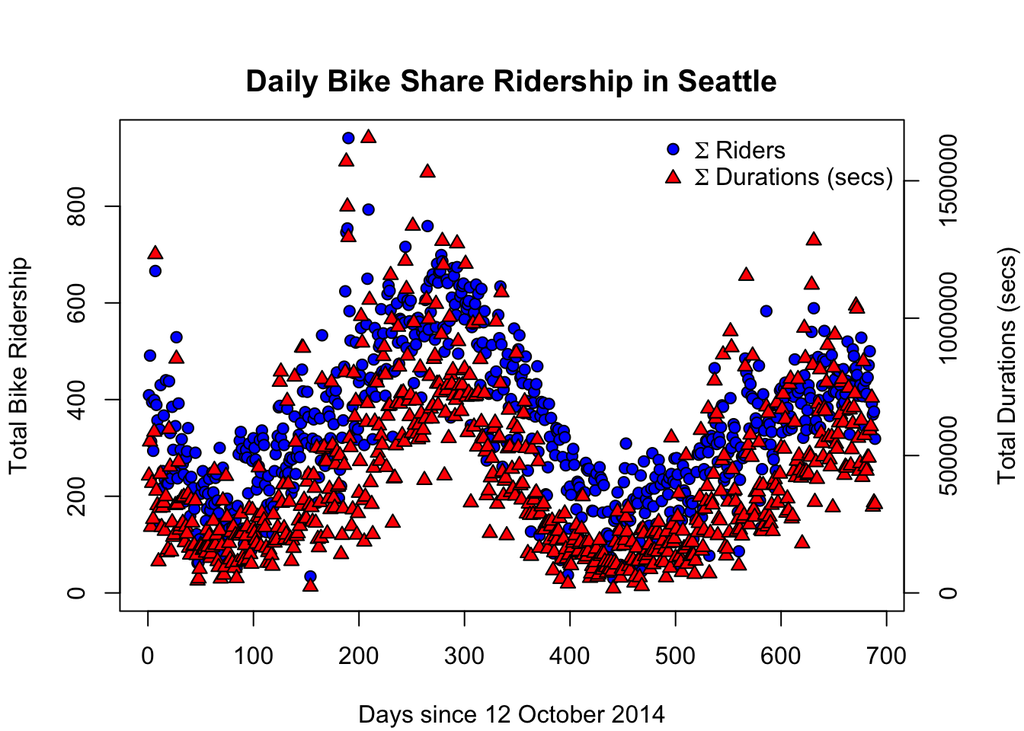

Daily Bike Share Ridership and Durations in Seattle.

# Methods

## Selecting the Response Variable

The three candidates for our response variable were created from the `trip.csv` data set, described in the `ridership` data frame, and merged into our final data frame: `total_trips`, `trip_durations`, and `avg_durations`. We briefly discuss the strengths of each response variable before a quantitative judgement:

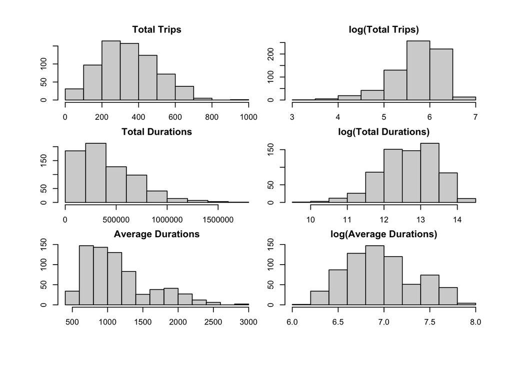

Variables Measuring Bike Share Ridership in Seattle

## Selecting the Predictors

For each of the continuous with recorded min, mean, and max –- Visibility, Temperature, Dew Point, Humidity, and Sea Level Pressure – we calculate their correlations with the response Total Trips. By feature, it turns out that Max Temperature, Min Visibility, Mean Dew Point, Mean Humidity, and Min Sea Level Pressure have the highest correlation with Total Trips (Table 2). Total Trips’ high correlation with Max Temperature may be explained by the temperature at midday, when the temperature is usually highest and when people are prone to be out biking. We added each of these highest-correlation variables with the response to our baseline model.

Wind speed is a special case with variables Max Wind Speed, Mean Wind Speed, and Max Gust Speed. Though had higher correlation with Total Trips than either or , it also had 410 missing values. We opted to add which had the next-highest correlation with Total Trips (Figure 3). We also added Precipitation_In (zero-inflated continuous variable) and Events (dummy variable based on whether a weather event occurred that day). We utilized Events in two ways. First we set it such that Event was a dummy variable representing whether there was an event that day. Events included fog, fog and rain, rain, rain and snow, rain and thunderstorm, and snow. There were 328 days where there were events and 361 without. The second way we utilized Events was by making it a dummy based on whether there was rain or snow on that day (as we might not expect a strong effect from fog).

Correlation between Weather Features and Total Trips

| Feature | Min | Mean | Max |
| --- | --- | --- | --- |
| Temperature (°F) | 0.640 | 0.750 | 0.786 |
| Visibility (miles) | 0.470 | 0.364 | 0.058 |
| Dew Point (°F) | 0.396 | 0.452 | 0.433 |
| Humidity (%) | -0.648 | -0.680 | -0.579 |
| Sea Level Pressure (in) | 0.180 | 0.079 | -0.065 |

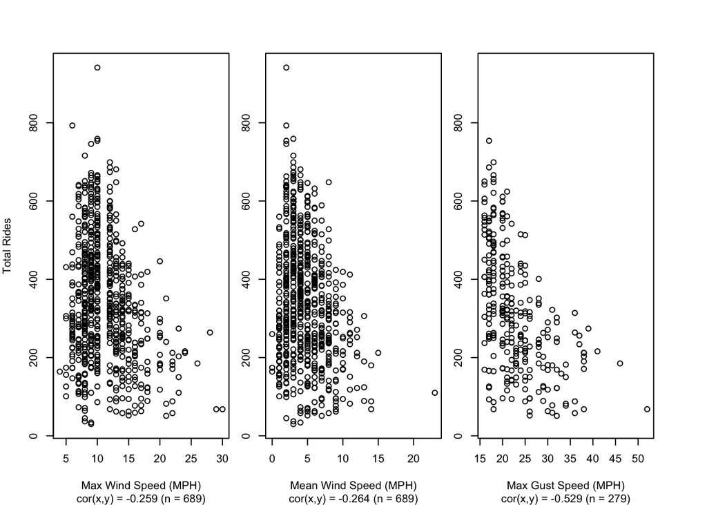

Effect of Wind Speed on Bike Share Ridership in Seattle.

## Model Selection

Our baseline model based on initial findings from exploratory data analysis is:

$$\begin{aligned}
\texttt{total\_trips}_i^{base} &= \beta_{i0} + \beta_{i1}
\texttt{Mean\_Humidity}_i + \beta_{i2} \texttt{MeanDew\_Point\_F}_i \\
&+ \beta_{i3} \texttt{Mean\_Wind\_Speed\_MPH}_i + \beta_{i4}
\texttt{Max\_Temperature\_F}_i + \beta_{i5}
\texttt{Min\_Visibility\_Miles}_i \\
&+ \beta_{i6} \texttt{Min\_Sea\_Level\_Pressure\_In}_i + \beta_{i7}
\texttt{Precipitation\_In}_i + \beta_{i8} \texttt{Events}_i \\
\end{aligned}$$

We removed , and because they were insignificant predictors for Total Trips Our full model at this point ($RSE$ = 83.09, $R^2$ = 0.7141, $R^2_{adj}$= 0.712, 0.01) is:

$$\begin{aligned}
\texttt{total\_trips}_i^{full} &= \beta_{i0} + \beta_{i1}
\texttt{Max\_Temperature\_F}_i + \beta_{i2} \texttt{MeanDew\_Point\_F}_i
\\
&+ \beta_{i3} \texttt{Mean\_Wind\_Speed\_MPH}_i + \beta_{i4}
\texttt{Mean\_Humidity}_i + \beta_{i5} \texttt{Precipitation\_In}_i \\
\end{aligned}$$
Cursory transformations failed to produce superior models. Application of a power transform produced coefficients that were mostly close to one. Both forwards and backwards selection failed to produce a superior model, although they selected models similar to ours. We discovered a partial model ($RSE$ = 83.45, $R^2$ = 0.7112, $R^2_{adj}$= 0.7095, ) with satisfactory summary statistics and diagnostic plots. The partial model is just the full model with the term dropped.

$$\begin{aligned}
\texttt{total\_trips}_i^{part} &= \beta_{i0} + \beta_{i1}
\texttt{MeanDew\_Point\_F}_i \\
&+ \beta_{i2} \texttt{Mean\_Wind\_Speed\_MPH}_i + \beta_{i3}
\texttt{Mean\_Humidity}_i + \beta_{i4} \texttt{Precipitation\_In}_i \\
\end{aligned}$$

Based on ANOVA / Partial $F$-test, the full model provides a better fit to the observed data over the partial model ($F$ = 6.9579, $p$ = 0.0085). However, Variance Inflation Factor ($VIF$) – measuring multicolinearity between the predictors and Total Trips – is abnormally high for ($VIF$ = 9.05), ($VIF$ = 10.68), and ($VIF$ = 19.09) in the full model.

It turns out that has high correlation with (0.72) and (-0.67). The results from $VIF$ analysis makes clear the confounding results in stepwise selection; In the forwards case, makes the best 1-predictor model and it is never eliminated in successive model. The partial model has VIF values near one. Thus, the partial model is the better model.

Finally, we strengthen our model by considering temporal variation. Adding the dummy variable accounts for weekly changes in ridership based on commute pattern changes in the downtown for leisure, work and school. Adding the variable accounts for changes in ridership based on the solstices and equinoxes while adding accounts for changes in ridership based only on the solstices:
$$\begin{aligned}
\texttt{total\_trips}_i^{temp} &= \beta_{i0} + \beta_{i1}
\texttt{MeanDew\_Point\_F}_i \\
&+ \beta_{i2} \texttt{Mean\_Wind\_Speed\_MPH}_i + \beta_{i3}
\texttt{Mean\_Humidity}_i + \beta_{i4} \texttt{Precipitation\_In}_i \\
&+ \beta_{i5} \texttt{weekday\_weekend}_i + \beta_{i6}
\texttt{season}_i + \beta_{i7} \texttt{fall\_winter}_i \\
\end{aligned}$$
Considering both the high correlation between variables and and the insignificance of the variable, we opt to drop this variable from our final model:

$$\begin{aligned}
\texttt{total\_trips}_i^{fin} &= \beta_{i0} + \beta_{i1}
\texttt{MeanDew\_Point\_F}_i \\
&+ \beta_{i2} \texttt{Mean\_Wind\_Speed\_MPH}_i + \beta_{i3}
\texttt{Mean\_Humidity}_i + \beta_{i4} \texttt{Precipitation\_In}_i \\
&+ \beta_{i5} \texttt{weekday\_weekend}_i + \beta_{i6}
\texttt{fall\_winter}_i \\
\end{aligned}$$

```
## [1] 63.54551
```

```
## [1] 84.79909
```

$$\begin{aligned}
\texttt{total\_trips}_i^{fin} &= 485.40 + 8.10
\texttt{MeanDew\_Point\_F}_i \\
&- 8.85 \texttt{Mean\_Wind\_Speed\_MPH}_i - 6.20
\texttt{Mean\_Humidity}_i - 103.49 \texttt{Precipitation\_In}_i \\
&- 50.23 \texttt{weekday\_weekend}_i - 34.11 \texttt{fall\_winter}_i
\\
\end{aligned}$$

# Conclusion

## Interpretations

Based on our model on any given day, holding all else equal, for a 1% increase in the mean relative humidity we expect 6.2 fewer trips. For a 1 degree Fahrenheit increase in the mean dew point, we expect 8.1 more trips. For a 1 inch increase in precipitation we expect 103.5 fewer trips. For a one mile per hour increase in the mean wind speed, we expect 8.8 fewer trips. For a day in fall or winter we expect 34.1 fewer trips than in summer or spring. For a day that is a weekend, we expect 50.2 fewer trips than on a weekday.

Rationalizing the signs of the coefficients, it makes sense for trips to drop as relative humidity rises, because higher a higher relative humidity is known to feel uncomfortable. It makes sense for trips to increase as the mean dew point increases, as a higher dew point generally coincides with warmer weather, which could make biking more comfortable. It makes sense that an increase in the inches of precipitation would decrease trips, as biking in rain or snow could be more dangerous and uncomfortable. The roads could be slippery and you could get soaking wet. It makes sense that an increase in the miles per hour of mean wind speed would decrease ridership, as faster winds increase wind chill which feels very uncomfortable, and biking into headwinds is tiresome. It makes sense that ridership decreases in the fall and winter, as this is when days are shorter, when Seattle’s rainy season starts, and when the leaves fall, potentially making it so that biking is slippery and less scenic. Lastly, an explanation for why ridership drops on the weekend is that many people likely used Pronto to get to work, which would not happen on the weekends.

## Extensions

Some possible extensions of our work here could be analyzing the relationships between weather and ridership in different cities. We might see different relationships between the weather and ridership in cities that have different climates than Seattle, for instance, Houston, Texas. Another potential extension would be to use interaction terms, and create a dummy variable for holidays, like a 2018 paper by Kyoungok Kim did.

# Appendix

## Code Used for Data Cleaning

```r
trip = read_csv('pronto-cycle-share-trip-data.csv')
# map unique dates to integers starting at 1
# strips the date from its current format
trip$date <- as.Date(trip$starttime, format = "%m/%d/%Y %H:%M")
unique_dates <- sort(unique(trip$date)) # this collects unique dates
# this maps unique date to the integers, starting at 1
date_to_number <- setNames(seq_along(unique_dates), as.character(unique_dates))
# this adds the integer mapping as a column, day_number
trip$day_number = date_to_number[as.character(trip$date)]
trip$count = 1 # this adds a one to each obs; useful for add
trip = dplyr::select(trip, count, tripduration, day_number)
```

```r
# construct new df, ridership, that aggregates trips by day
ridership = trip %>% group_by(day_number) %>%
  summarise(total_trips = sum(count),
            total_durations = round(sum(tripduration), 1),
            .groups = 'drop'); dim(ridership)
```

```r
weather = read_csv('weather.csv.xls')
# calculates temperature range for each day
weather$temp_range = weather$Max_Temperature_F - weather$Min_TemperatureF
# strips the date from its current format
weather$date <- as.Date(weather$Date, format = "%m/%d/%Y")
# maps unique date to the integers, like the chunk above
date_to_number <- setNames(seq_along(unique_dates), as.character(unique_dates))
weather$day_number = date_to_number[as.character(weather$date)]
weather = weather[,-1] # remove the old date
# this will be our data frame going forward
df = left_join(weather,ridership, by='day_number'); dim(df)
df$avg_durations = round(df$total_durations / df$total_trips, 1)
```

```r
df$weekday_weekend <- ifelse(weekdays(df$date) %in% c("Saturday", "Sunday"),1,0)
# Define a function to classify seasons based on actual start dates
get_season <- function(date) {
  year <- lubridate::year(date)
  spring_start <- as.Date(paste0(year, "-03-20"))
  summer_start <- as.Date(paste0(year, "-06-21"))
  fall_start   <- as.Date(paste0(year, "-09-22"))
  winter_start <- as.Date(paste0(year, "-12-21"))
  ifelse(date >= spring_start & date < summer_start, 0,  # Spring
  ifelse(date >= summer_start & date < fall_start,   1,  # Summer
  ifelse(date >= fall_start & date < winter_start,   2,  # Fall
  3)))  # Winter
}
# Apply the function to the 'date' variable
df$season <- sapply(df$date, get_season)
# Create fall/winter dummy: 1 if Fall or Winter, 0 otherwise
df$fall_winter <- ifelse(df$season %in% c(2, 3), 1, 0)
```

## Summary Statistics for Final Model

```
##
## Call:
## lm(formula = total_trips ~ Mean_Humidity + MeanDew_Point_F +
##     Precipitation_In + Mean_Wind_Speed_MPH + fall_winter + weekday_weekend,
##     data = df)
##
## Residuals:
##     Min      1Q  Median      3Q     Max
## -221.24  -51.52   -3.87   45.97  442.98
##
## Coefficients:
##                      Estimate Std. Error t value Pr(>|t|)
## (Intercept)          485.3972    25.9669  18.693  < 2e-16 ***
## Mean_Humidity         -6.1999     0.3101 -19.995  < 2e-16 ***
## MeanDew_Point_F        8.1029     0.4673  17.338  < 2e-16 ***
## Precipitation_In    -103.4870    14.9002  -6.945 8.82e-12 ***
## Mean_Wind_Speed_MPH   -8.8492     1.1689  -7.570 1.21e-13 ***
## fall_winter          -34.1058     8.7685  -3.890  0.00011 ***
## weekday_weekend      -50.2268     6.7387  -7.453 2.76e-13 ***
## ---
## Signif. codes:  0 '***' 0.001 '**' 0.01 '*' 0.05 '.' 0.1 ' ' 1
##
## Residual standard error: 79.64 on 682 degrees of freedom
## Multiple R-squared:  0.7378, Adjusted R-squared:  0.7354
## F-statistic: 319.8 on 6 and 682 DF,  p-value: < 2.2e-16
```

## Diagnostic Plots for Final Model

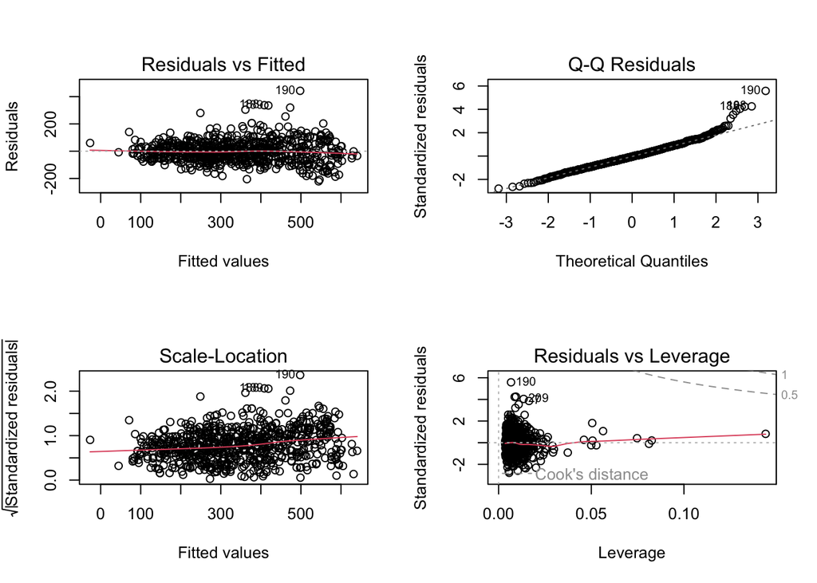